# Análise dos gastos dos deputados paraibanos

8 de julho de 2016

```r
library(dplyr, warn.conflicts = FALSE)
library(ggplot2)
library(knitr)
theme_set(theme_bw())
```

Como os deputados paraibanos gastam sua cota para exercício da atividade parlamentar?

Aqui os dados são carregadas e filtrados para considerar apenas deputados do estado da Paraíba. Além disso, apenas algumas variáveis serão levadas em conta: PARTIDO (Partido), NOME DO DEPUTADO (Nome), ESTADO(UF), TIPO DE DESPESA (Descricao) e VALOR LÍQUIDO (Valor_liquido), ou seja, aquilo que foi de fato debitado da conta do deputado.

```r
ler_gastos <- function(arquivo = "dados/ano-atual.csv"){


  #' Lê um csv criado a partir dos dados de gastos dos deputados da
  #' Câmara e seta os tipos de colunas mais convenientemente.
  #' Versão sem readr, para máquinas onde não é possível instalar esse pacote.
  #' É um pouco mais lenta que a com readr.
  require("dplyr", warn.conflicts = FALSE)

  gastos = read.csv(arquivo, stringsAsFactors = FALSE, encoding='UTF-8')
  gastos = gastos %>%
    mutate_each(funs(as.factor), sgPartido, sgUF, txNomeParlamentar, indTipoDocumento)
  return(gastos)
}


gastos <- ler_gastos()

gastos <- gastos %>% select (1, 5, 6, 15, 23)

names(gastos) <- c("Partido", "Nome", "UF", "Descricao", "Valor_liquido")

gastos_pb <- gastos %>% filter (UF == "PB")
```

## Centralidade, extremos, concentração e simetria.

Aqui é analisado o resumo de todas as despesas (valor líquido) feitas pelos deputados, ainda não levando em conta seu tipo (Podemos ter gastos diferentes para uma mesma categoria como TELEFONIA, por exemplo). O principal objetivo dessa análise foi verificar algo um tanto quanto estranho, que é a existência de observações cujo o valor da despesa é negativo. Isso acontece para situações de emissão de bilhetes aéreos, significando que o referido bilhete é um bilhete de compensação, pois compensa um outro bilhete emitido e não utilizado pelo deputado.

```r
summary(gastos_pb $ Valor_liquido)
```

```
##    Min. 1st Qu.  Median    Mean 3rd Qu.    Max.
## -2820.0    70.0   190.0   847.9   639.0 41890.0
```

Agora, vamos focar em observar os gastos de cada deputado no geral, somando todas as suas despesas. Inicialmente, observando o resumo, temos que o deputado que mais gastou durante o período observado gastou aproximadamente R$ 242 700, enquanto o mínimo foi aproximadamente R$ 41 880. 25% dos deputados gastaram aproximadamente R$ 124 700 ou menos e 75% gastaram R$ 206 100 ou menos.

```r
agrupa_nome = gastos_pb %>%
  group_by(Nome) %>%
  summarise(total_gasto = sum(Valor_liquido))

summary(agrupa_nome$total_gasto)
```

```
##    Min. 1st Qu.  Median    Mean 3rd Qu.    Max.
##   41880  124700  168400  162900  206100  242700
```

Gerando um gráfico de barras para observar melhor tais extremos, vemos que Pedro Cunha Lima foi o deputado que menos gastou (aproximadamente $ 41 900) e Rômulo Gouveia o deputado que mais gastou (Aproximadamente $ 242 654) . Um ponto surpreendente notável é a diferença exorbitante de gastos de Pedro para os demais deputados. O mais indicado para um analista de dados seria pesquisar algo sobre o ponto estranho a fim de encontrar uma razão. Na verdade, Pedro Cunha Lima se afastou do cargo no fim do ano passado para terminar o seu mestrado, o que explica esse pequeno valor gasto. Seu substituto, Marcondes Gadelha, inclusive, é o segundo que menos gastou.

Os deputados gastam em média, R$ 162 900, e a mediana é aproximadamente R$ 168 400, valores não tão distantes quando leva-se em conta a ordem de grandeza dos valores envolvidos. O mesmo gráfico mostra essas linhas, com a média em vermelho e a mediana em azul.

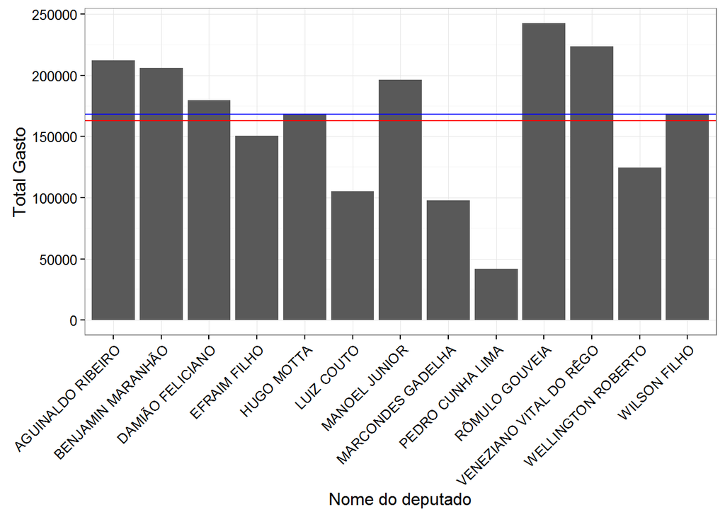

```r
ggplot(agrupa_nome, aes(x= Nome, y = total_gasto)) + geom_bar(stat = "summary", fun.y = "mean") + theme(axis.text.x = element_text(angle = 45, hjust = 1), panel.background=element_blank()) + xlab("Nome do deputado") + ylab("Total Gasto") +

geom_abline(intercept = mean(agrupa_nome$total_gasto), slope = 5, colour = "red") +

  geom_abline(intercept = median(agrupa_nome$total_gasto), slope = 5, colour = "blue")
```

Agora, temos um gráfico de dispersão com a distribuiçao dos deputados e seus gastos. Os parlamentares estão bem espalhados pelo gráfico, mas podemos notar que o maior ponto de concentração é entre os valores gastos de 150 000 e 200 000, onde temos cinco deputados. Outra forma de observar isso é através de um histograma, onde concluimos a existência de uma classe modal, ou seja, onde aparecem mais ocorrências, que é exatamente o intervalo citado anteriormente (Entre 150 mil e 200 mil)

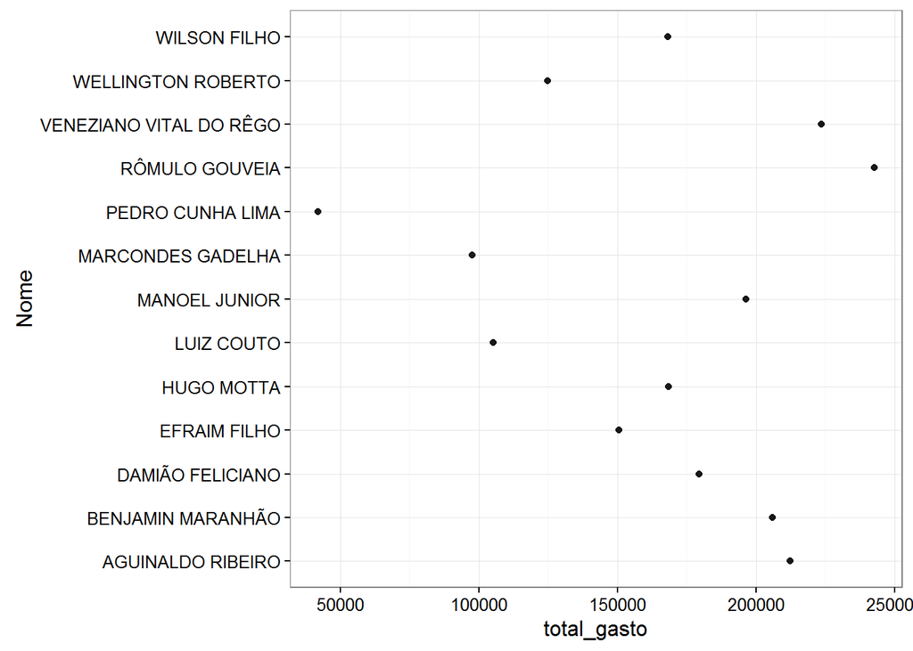

```r
ggplot(data = agrupa_nome) +
  geom_point(mapping = aes(x = Nome,
                           y = total_gasto),
             alpha = 0.9) + coord_flip()
```

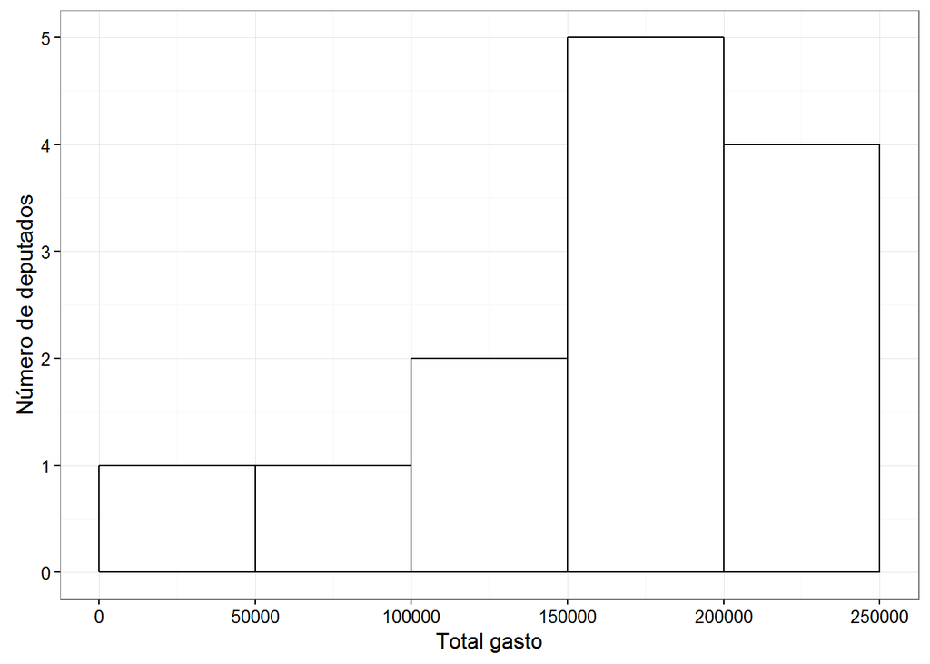

```r
ggplot(agrupa_nome) +
  geom_histogram(mapping = aes(x = total_gasto),
                 fill = "white",
                 colour = "black",
                 breaks = c(0, 50000, 100000, 150000, 200000, 250000)) + xlab("Total gasto") + ylab("Número de deputados")
```

Esse gráfico boxplot também ajuda a tirar algumas conclusões dos dados, principalmente a respeito de simetria e concentração.

Os dados são poucos assimétricos, já que mediana divide o retângulo praticamente pela metade. Aproximadamente metade dos deputados gasta entre 124 mil e 206 mil, que são os pontos observados exatamente dentro do retângulo.

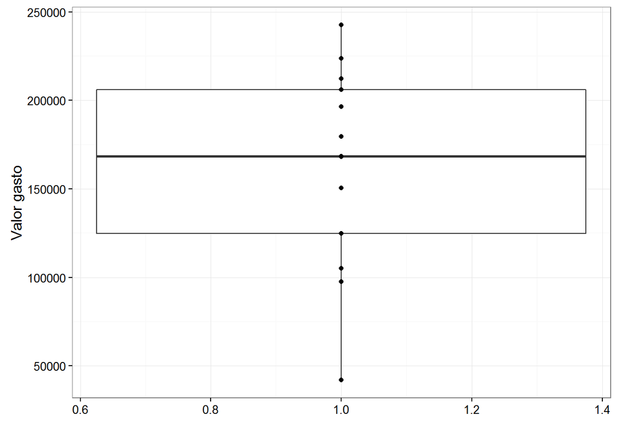

```r
ggplot(agrupa_nome, mapping = aes(x = 1, y = total_gasto)) + geom_boxplot() + geom_point(position=position_dodge(width=0.75) ) + labs(x='', y='Valor gasto')
```

## COM O QUE NOSSOS DEPUTADOS MAIS GASTAM?

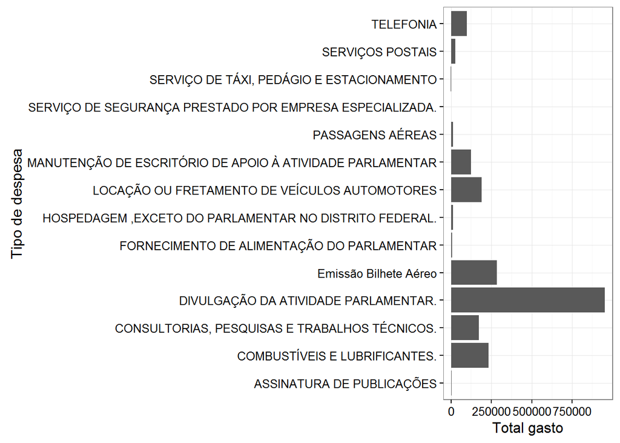

```r
agrupa_categoria = gastos_pb %>%
  group_by(Descricao) %>%
  summarise(total_gasto = sum(Valor_liquido))

ggplot(agrupa_categoria, aes(x= Descricao, y = total_gasto)) + geom_bar(stat = "identity") + coord_flip() + ylab("Total gasto") + xlab("Tipo de despesa")
```

## QUAIS OS TIPOS DE DESPESAS QUE MAIS VARIAM?

As despesas com Divulgação da atividade parlamentar são as que mais variam, possuindo um desvio padrão aproximado de 5026. Consultorias, Pesquisas e Trabalhos Técnicos é o segundo tipo de despesa que mais varia. A emissão de bilhetes aéreos, que é o serviço mais solicitado e o segundo com o qual os deputados mais gastam, apresenta pouca variação.

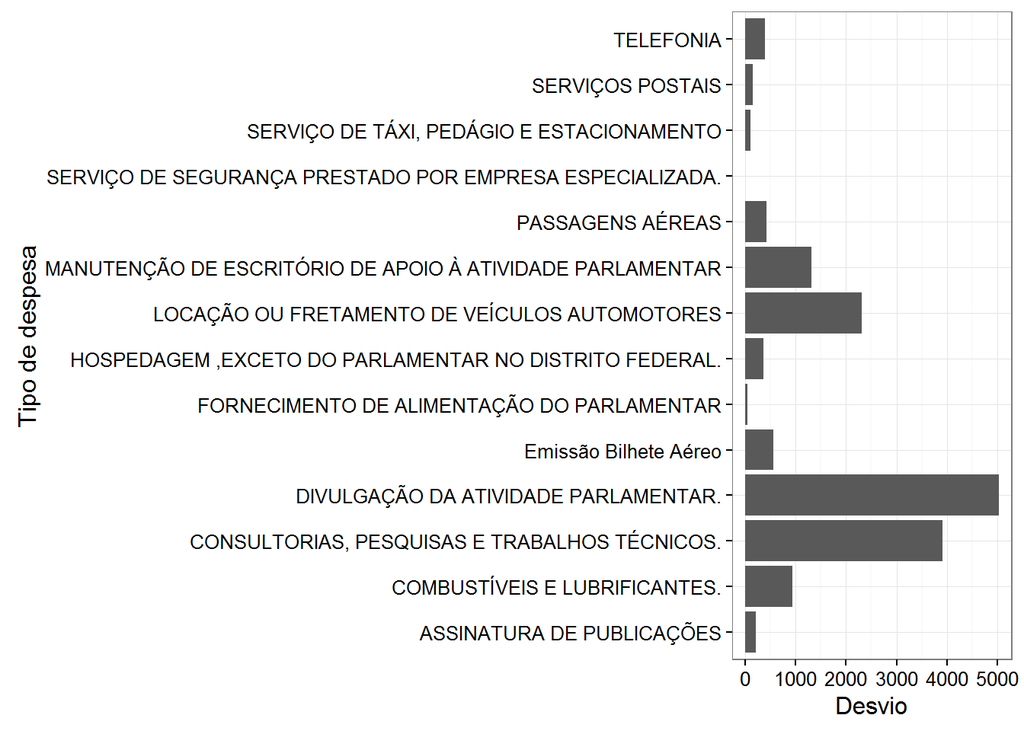

```r
agrupa_categoria = gastos_pb %>%
  group_by(Descricao) %>%
  summarise(desvio_padrao = sd(Valor_liquido))

ggplot(agrupa_categoria, aes(x= Descricao, y = desvio_padrao)) + geom_bar(stat = "identity") + coord_flip() + ylab("Desvio") + xlab("Tipo de despesa")
```

Observando com mais cuidado o tipo de despesa com maior variação de despesa (DIVULGAÇÃO DA ATIVIDADE PARLAMENTAR), pode-se notar que temos uma enorme variação de valores nessa categoria realmente. O valor mínimo observado em uma despesa foi de “apenas” R$ 334,30, e o maior valor chega a ultrapassar os R$ 41 000. O deputado Benjamin Maranhão, por exemplo, detentor da maior despesa da categoria citado agora a pouco, possui despesas do mesmo tipo que estão na casa dos R$ 500.

```r
atividade_parlamentar <- gastos_pb %>% filter(Descricao == "DIVULGAÇÃO DA ATIVIDADE PARLAMENTAR.")

summary(atividade_parlamentar$Valor_liquido)
```

```
##    Min. 1st Qu.  Median    Mean 3rd Qu.    Max.
##   334.3  1000.0  2000.0  3980.0  5000.0 41890.0
```

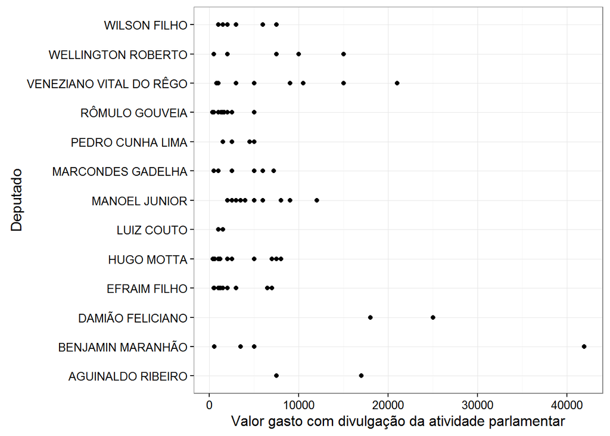

```r
ggplot(atividade_parlamentar, aes(x = Nome, y = atividade_parlamentar$Valor_liquido)) + geom_point() + coord_flip()  + ylab("Valor gasto com divulgação da atividade parlamentar") + xlab("Deputado")
```